# Job Vacancies and Labour-Market Slack in Australia

Examining Short-Run Changes in Labour Demand and Slack

Trisha Andrea

Rimlan Alva

19 October 2026

## Why does this matter?

### Labour demand & slack

**Job vacancies** indicate employers’ demand for workers.

**Labour-market slack** shows how much available labour is not fully utilised.

### The key idea

**Higher labour demand**

⬇

**More job vacancies**

⬇

**Potentially less labour-market slack**

## Research Question

### To what extent are changes in **job vacancies** associated with short-run changes in **labour-market slack** in Australia?

## Data

We use Australian labour-market data from **ABS** and **Jobs and Skills Australia**.

### Labour Demand

**ABS Job Vacancies**  
Quarterly vacancies · *Main analysis*

**JSA Internet Vacancy Index**  
Monthly online job advertisements · *Additional exploration*

### Labour-Market Slack

**ABS Labour Force**

- **Unemployment** — without work
- **Underemployment** — wants more hours
- **Underutilisation** — combines both

## Methodology

### 1. Calculate short-run changes

**Quarter-to-quarter:**

Δ Job Vacancies  
Δ Unemployment · Δ Underemployment · Δ Underutilisation

### 2. Compare vacancy and slack changes

**Δ Vacancies ↔︎ Δ Slack**

### 3. Examine the relationship

**Scatter plots · Trend analysis · Correlations**

## Labour-Market Tightness Over Time

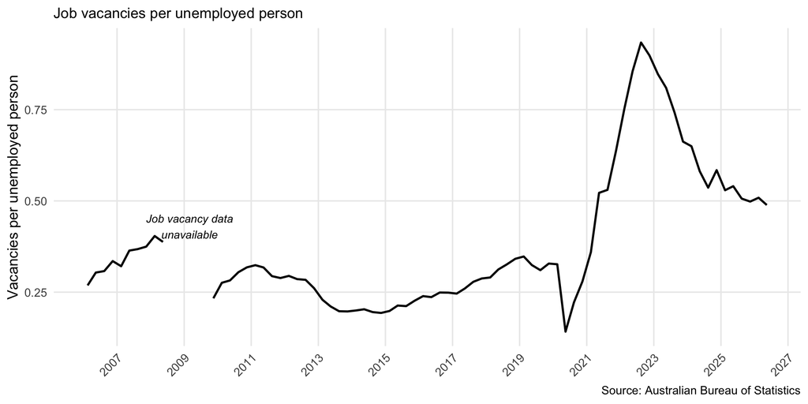

## Tightness and Labour-Market Slack

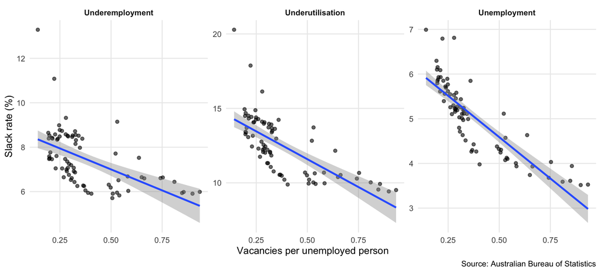

## Interactive Labour-Market Dashboard

**Exploring Australia’s labour market interactively**

*Live Shiny demonstration*

## Main Results

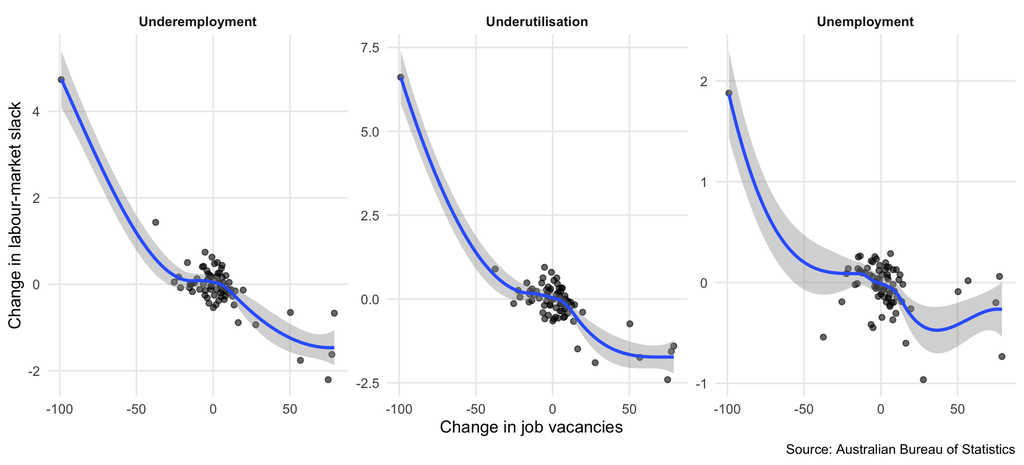

## Interpretation & Limitations

### Interpretation

**↑ Job vacancies → ↓ Labour-market slack**

The negative association appears across all three slack measures.

### Limitations

- **Association does not imply causation**
- Economic shocks may affect both vacancies and slack
- Some periods have missing job-vacancy data

## Conclusion

### What did we find?

Changes in job vacancies are **negatively associated** with short-run changes in labour-market slack.

The pattern is observed across:

**Unemployment · Underemployment · Underutilisation**

### Key takeaway

**Stronger labour demand tends to coincide with lower labour-market slack.**